# Convolutional Networks

## Now let's see how bad our model is

```python
#evaluate our model using it evaluate attribute
metric_values = model_1.evaluate(x=test_images, y=test_labels)

#display the final result
print('Final TEST performance')
for metric_value, metric_name in zip(metric_values, model.metrics_names):
    print('{}: {}'.format(metric_name, metric_value))
```

[output not shown]

## now let's see if our model can predict or guess well

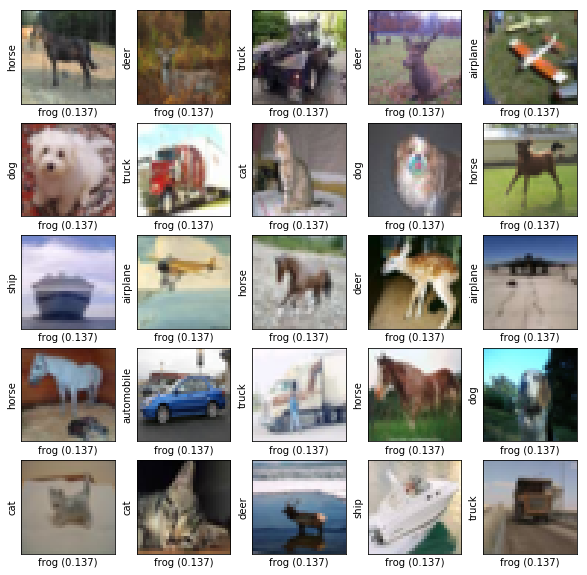

```python
#collecting some random sample
img_indices = np.random.randint(0, len(test_images), size=[25])
sample_test_images = test_images[img_indices]
sample_test_labels = [cifar_labels[i] for i in test_labels[img_indices].squeeze()]

#test the model on the samples colected
predictions = model_1.predict(sample_test_images)
max_prediction = np.argmax(predictions, axis=1)
prediction_probs = np.max(predictions, axis=1)

# display the result predicted vs the real image
plt.figure(figsize=(10,10))
for i, (img, prediction, prob, true_label) in enumerate(
    zip(sample_test_images, max_prediction, prediction_probs, sample_test_labels)):
    plt.subplot(5,5,i+1)
    plt.xticks([])
    plt.yticks([])
    plt.grid('off')

    plt.imshow(img)
    plt.xlabel('{} ({:0.3f})'.format(cifar_labels[prediction], prob))
    plt.ylabel('{}'.format(true_label))
```

# Why do modern architectures use less max-pooling?

Because this method is based on the idea of simplifying the process by pooling the the max value in a given array, therefore it somehow discard important information that could be usefull when looking for variance in the data.

https://principlesofdeeplearning.com/index.php/2018/08/27/is-pooling-dead-in-convolutional-networks/

# What does a 1x1 convolution do?

A 1x1 convolution simply maps an input pixel with all it's channels to an output pixel, not looking at anything around itself. It is often used to reduce the number of depth channels, since it is often very slow to multiply volumes with extremely large depths. https://stats.stackexchange.com/questions/194142/what-does-1x1-convolution-mean-in-a-neural-network

# What is a residual connection?

simply put: connecting the OUTPUt of layer1 to the OUTPUT of layer2

in simple equation we will say if y=f(x) in standard connection.

in Residual connection the equation wi be y=f(x)+x. x being the output